## Lettre de soutien au CSBQ [FR]

*En réponse à la décision du FQRNT de potentiellement retirer son support financier du CSBQ, Gabrielle Rimok (Concordia), Mariane Daneau-Lamoureux (UQAM/McGill), et Maëlle Tripon (UdeS), avec l’aide d’Audrey Sigouin (UdeS), Katherine Hébert (UdeS) et des étudiants du cours intensif 2019 en science de la biodiversité du CSBQ, ont préparé une lettre de soutien (ci-dessous) pour accompagner la demande de refinancement du CSBQ.*

Le FRQNT (Fonds de Recherche du Québec – Nature et Technologies) a récemment réduit son soutien financier du Centre de la Science de la Biodiversité du Québec (CSBQ) et demande une justification de la valeur stratégique du centre, de sa recherche, et de ses formations. À la lumière de cette situation, nous, les étudiants.es, post-doctorants.es et chercheurs.euses d’une variété de disciplines liées aux sciences de la biodiversité, tenons à exprimer notre soutien au CSBQ.

La mission du Fonds de Recherche du Québec – Nature et Technologies (FRQNT) est telle que:

- *promouvoir et fournir un support financier : pour la recherche dans les domaines des sciences naturelles; pour la dissémination du savoir scientifique dans les domaines de recherche associés aux sciences naturelles; pour la formation des chercheurs à travers l’obtention de bourses pour étudiants gradués et post-gradués*;
- *créer tous les partenariats nécessaires, en particulier avec les universités, les collèges et l’industrie, les ministères et les organismes publics et privés concernés*.

Depuis ses 10 ans de création, le CSBQ est un pôle de recherche multidisciplinaire qui rassemble des étudiants.es et chercheurs.euses de tout le Québec, du Canada et de l’étranger. Le CSBQ joue un rôle essentiel dans la formation de personnel hautement qualifié en sciences de la biodiversité par l’entremise de programmes de formation multiples et variés. Ces derniers présentent des opportunités uniques de réseautage entre étudiants.es gradués.ées, post-doctorants.es et chercheurs.euses internationalement reconnus dans leur domaine et affiliés.ées au CSBQ. La création de ces liens est primordiale à l’établissement de relations interpersonnelles et professionnelles entre les différents acteurs impliqués dans les sciences de la biodiversité.

Le CSBQ vise à assurer le partage des connaissances et la multidisciplinarité dans une optique de gestion et de conservation de toute la biodiversité au Québec et à l’international. Le CSBQ offre de nombreuses activités de formation tels que des groupes de travail, séminaires, symposiums et divers cours de niveau avancé, qui sont pour nous, étudiants.es gradués.ées et post-doctorants.es, un avantage indéniable dans l’acquisition de compétences avancées en statistiques et en communication scientifique. Les aptitudes développées grâce au CSBQ sont fondamentales dans la poursuite de nos carrières académiques et professionnelles.

Le CSBQ a à cœur l’accessibilité de ses formations sans discrimination. Le CSBQ assure une éducation de haute qualité pour tous.tes en retirant les barrières financières, linguistiques et mobiles qui pourraient empêcher une personne d’y avoir accès. Les événements de partage de connaissances et de communication scientifique permettent aux étudiants.es d’en apprendre davantage sur les nombreux domaines de recherche englobés par le thème de la biodiversité et sur les multiples acteurs impliqués, tant au niveau académique que social et juridique.

Le CSBQ contribue à faire du Québec un chef de file en alliant Science et Politique, permettant l’utilisation des meilleures pratiques de gestion et de conservation de la biodiversité. Les collaborations établies par le CSBQ entre chercheurs.euses, professionels.elles, et décideurs.euses politiques ont créé une communauté soutenant la recherche et des formations de calibre mondial au Québec. Un objectif central au CSBQ est de former la prochaine génération d’experts de la biodiversité au Québec et de faire rayonner le Québec au Canada et à l’étranger.

C’est pour l’ensemble des raisons mentionnées ci-dessus que nous demandons le maintien du support financier du programme de regroupements stratégiques du FRQNT envers le CSBQ.

## Letter of support to the QCBS [EN]

*In response to the FRQNT’s decision to potentially withdraw its financial support from the QCBS, Gabrielle Rimok (Concordia), Mariane Daneau-Lamoureux (UQAM/McGill), and Maëlle Tripon (UdeS), with help from Audrey Sigouin (UdeS), Katherine Hébert (UdeS) and students from the 2019 QCBS Biodiversity Science course, prepared a support letter to accompany the QCBS’ renewal application.*

The FRQNT (Front de Recherche du Québec - Nature et Technologies) has reduced financial support to the QCBS (Québec Centre for Biodiversity Science) and has requested a justification for the strategic value of the centre, its research, and training. In light of this, we, students, postdoctoral fellows and researchers from a variety of disciplines working in the biodiversity sciences, want to express our strongest support for the QCBS.

The mission of the Fonds de Recherche du Québec – Nature et Technologies (FRQNT) is as follows:

- *to promote and provide financial support: for research in the fields of natural sciences; for the dissemination of scientific knowledge in fields of research relating to natural sciences; for the training of researchers through scholarships for graduate and postgraduate students*;
- *to create any necessary partnerships, in particular with universities, colleges, and industry and the government departments and public and private bodies concerned*.

Since its inception 10 years ago, the QCBS has provided a multidisciplinary research pole that has brought together students and researchers from all over Québec, Canada, and abroad. The QCBS plays an essential role in the training of highly qualified personnel in biodiversity sciences through multiple and varied training programs. This has provided unique networking opportunities between graduate students, postdoctoral fellows and researchers internationally recognized in their field and affiliated with the QCBS. The creation of such links is primordial for the establishment of interpersonal and professional relationships between the various researchers and actors in the field of biodiversity sciences.

The QCBS aims to ensure knowledge sharing and multidisciplinarity in the perspective of biodiversity management and conservation in Québec and abroad. The QCBS offers many training activities, such as working groups, seminars, symposia and various advanced level courses, which are for us, graduate and postdoctoral students, an opportunity to acquire advanced skills in statistics and scientific communication, among many others. The skills developed through the QCBS are fundamental to the pursuit of our academic and professional careers.

The QCBS is committed to making its training accessible to all and without discrimination. The QCBS provides high-quality education for all by removing financial, linguistic, and mobility barriers that would otherwise prevent a person from having access to it. Equity and diversity is a key focus for the QCBS. Knowledge sharing and training in scientific communication allow students to learn more about the many areas of research encompassed by the field of biodiversity science and the multiple actors in academia, and the public and private sectors of society.

The QCBS is providing leadership, both nationally and internationally, by bridging the gap between science and policy, and via the application of best practices for biodiversity management and conservation. The collaborations established by the QCBS among researchers, practitioners, and policymakers have created a community, supporting world-class research and training in Québec. A central mission of the QCBS is to train the next generation of biodiversity scientists in Québec and foster the leadership role Québec is providing in Canada and abroad.

It is for all of the above-mentioned reasons that we urge the strategic cluster program of the FRQNT to continue its funding for the QCBS.

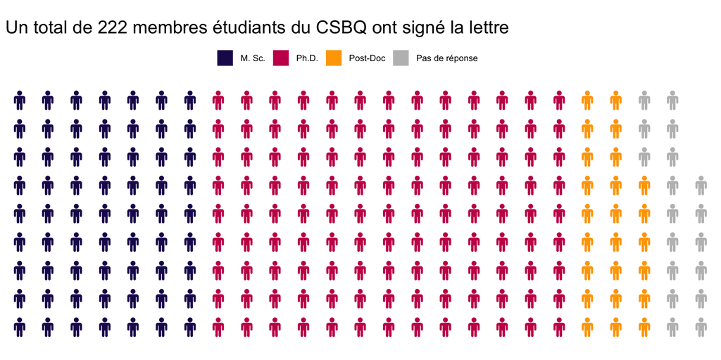

## Portrait des répondants

### Membres étudiants actuels du CSBQ

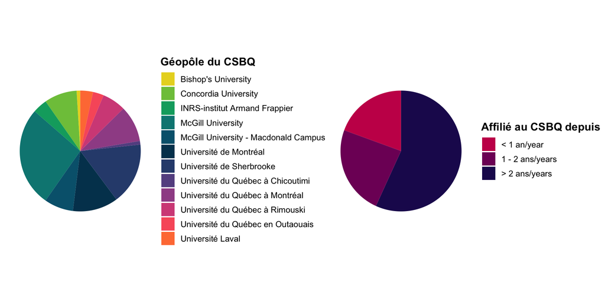

### Anciens membres étudiants du CSBQ

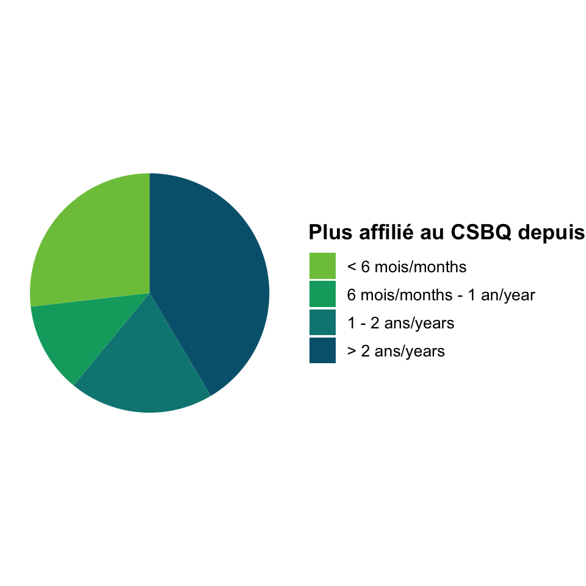

Depuis avoir quitté le CSBQ, nos anciens membres étudiants contribuent de diverses manières à l’avancement de la science de la biodiversité en milieux académiques et professionnels. Voici quelques exemples de rôles actuellement occupés par des anciens membres étudiants du CSBQ:

| Assistant de recherche, musée redpath |
| --- |
| Assistant professor - university of waterloo (on) |
| Associate asset manager @ edf renewables |
| Chargée de cours et professionnelle de recherche |
| Collaboratrice de recherche dans un projet de la chaire de recherche sur les enjeux sociaux de la conservation |
| Data analyst for biodiversity conservation |
| Government - research |
| Research on community phylogenetics of tropical trees at western ghats southern india. |
| I’m an advisor for the office of research and innovation |
| Just graduated! |
| Professionnel de recherche en phytoprotection |
| Professionnelle de recherche |
| Program coordinator at mcgill |
| Quantitative biologist with eccc |
| Research assistant |
| Research associate and adjunct professor |
| Research associate at mcgill |
| Scientific research |
| Started a company |
| Sur le marché du travail |
| Technicienne de recherche |
| Work for undp ecosystem and biodiversity team |

## Vision du CSBQ des étudiants / Students’ view of the QCBS

### Impact des activités du CSBQ sur nos carrières académiques et professionnelles

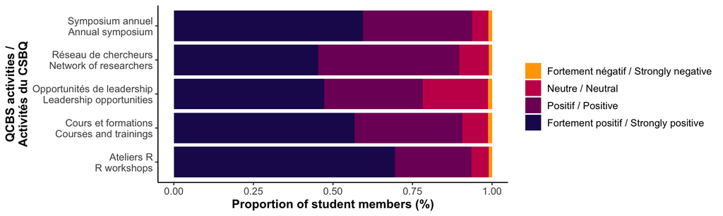

Quelques exemples d’impacts **fortement positifs** sur les parcours académiques et/ou les carrières professionnelles des répondants:

| Améliorer mes compétences en R |
| --- |
| Les ateliers R sont extrêmement pertinents et m’ont permis de réviser des notions fondamentales au bon déroulement de ma maîtrise |
| Les ateliers R me permettent de mener mes analyses pour mon doctorat, et ce serait très long et compliqué sans eux. De plus le CSBQ permet de créer un réseau de chercheurs que l’ont peut contacter pou… |
| Coordonner les ateliers en R du CSBQ m’a permis d’acquérir de solides expériences d’enseignement et d’établir ma crédibilité en tant qu’analyste de données. |
| Le colloque annuel m’a permis de présenter mon projet de recherche à l’ensemble des chercheurs/étudiants présents. Ce partage d’informations nous permet à tous, d’apprendre et d’échanger sur les probl… |
| L’occasion de présenter mes recherches |
| Le colloque annuel m’a permis de présenter mon projet de recherche à l’ensemble des chercheurs/étudiants présents. Ce partage d’informations nous permet à tous, d’apprendre et d’échanger sur les probl… |
| Le CSBQ m’a permis de m’impliquer avec le Beagle et donc de développer mon intérêt pour la communication scientifique. Le colloque du CSBQ est aussi une opportunité incroyable pour rencontrer de nouve… |
| QCBS provided support for the Montreal Eco Evo Symposium (MEES) in December 2019, which provided me with fantastic opportunities to meet and network with other scientists in the program. Although I di… |
| It’s given me the skills and network necessary to complete my graduate degree. |
| Le colloque du CSBQ m’a permis d’élargir mon réseau et de rencontrer des chercheurs et étudiants qui m’ont donné des conseils précieux pour l’avancement de mon projet de thèse. |
| Tous les ateliers R que j’ai réçu ont été très utiles pour le développement de ma thèse de doctorat. |
| The intensive GIS courses and R courses greatly advanced my statistical knowledge and contributed to my success in my current position within the federal government |
| Les ateliers R m’ont énormément aidés et sont une des meilleures resources du genre |
| I attended the 2019 Biodiversity Science course held by the QCBS. The course was one of the best courses I have taken during my studies. I was able to interact not only with MSc. and PhD students from… |
| Le CSBQ a été un moteur majeur – autant voir plus que mon université – dans le développement de mes compétences (autant scientifiques que de leadership ou encore de communication) et de mon réseau. Pa… |
| QCBS gave me the opportunity to do a project with other researchers that would never have happened without the Seed Grant. This collaboration lead to the start of a new business and my career! |
| D’abord, j’apprécie grandement les colloques du CSBQ chaque année. C’est un rassemblement entre les chercheurs du Québec à ne pas manquer. Le CSBQ a aussi beaucoup contribué dans mon parcours en m’aid… |
| The QCBS has supported me throughout the entire duration of my graduate studies, allowing me to learn diverse new skills, and expand my studies into much more than they ever could have been without th… |
| Gave me skills from workshops to improve my CV for job prospects |
| J’ai participer à l’organization et la structuration du CSBQ (Drive, évaluation du CSBQ, développement d’ateliers (e.g. LMM), organization d’évènements lors des conférences, travaillé à la red.couvert… |
| Bringing me to Canada from the USA . |
| The QCBS workshops have given me opportunities to learn skills that I would otherwise not have been able to learn in my normal university curriculum. |
| Through QCBS, I have been able to meet and collaborate with many different researchers from institutions across Quebec that I would not have had the opportunity to do so otherwise. |
| The R workshops have been instrumental in helping our lab to learn this essential coding language. These workshops are crucial for burgeoning life scientists with limited computer science and statisti… |
| The QCBS has given me many fantastic opportunities that I would otherwise not have had, including practicing French. Another example, we invited a researcher to come and teach us a method he had devel… |
| Les ateliers R m’ont beaucoup aidé à mieux comprendre les statistiques, mieux maîtriser R pour les appliquer et mieux comprendre dans quels contextes les utiliser. |
| à titre d’exemple, les ateliers R m’ont permis de vraiment mieux comprendre le logiciel et le langage, que je ne comprenais vraiment que très peu auparavant. Comme il s’agit d’un atout important dans … |
| En plus d’avoir financé une partie de mon terrain de recherche, grâce au CSBQ mes aptitudes à utiliser R, GIMP ainsi que Inkscape ont fortement augmenté. |
| Le CSBQ est une plateforme unique pour créer/consolider un réseau professionnel et scientifique, permettant de développer des projets de recherche interdisciplinaires de haut niveau scientifique. Il e… |
| J’ai participé au cours intensif sur la science de la biodiversité en 2017. J’y ai appris énomément, et surtout, j’ai pu créer des liens avec plusieurs chercheurs et étudiants-chercheurs. |

[output cut: 117 more lines]

### L’importance du soutien financier offert par le CSBQ

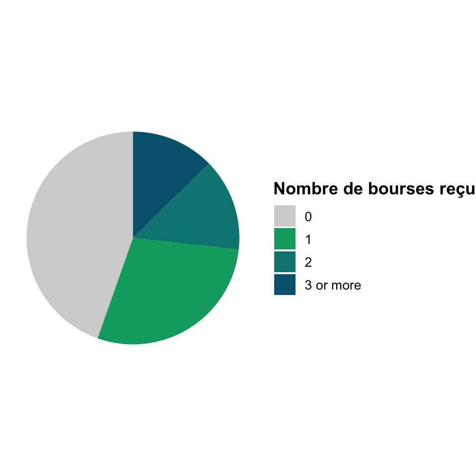

Une majorité des étudiants **(85%)** sont d’accord ou fortement d’accord que les bourses du CSBQ leur ont permis d’accéder à des opportunités qui seraient **autrement impossibles**.

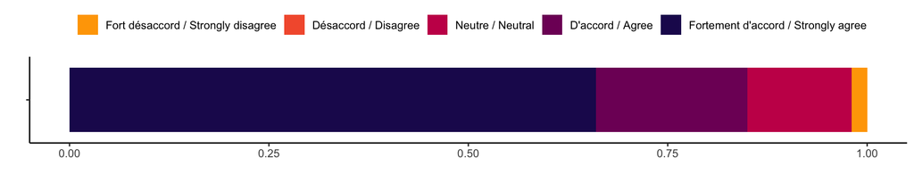

### Développement de chercheur(e)s

La majorité des étudiants **(93.8%)** évaluent que le CSBQ a eu un impact positif ou fortement positif sur leur développement en tant que chercheur(e).

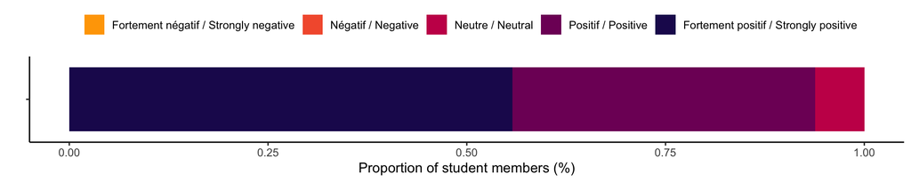

## Ce que le CSBQ apporte aux étudiants

| Apprendre et approfondir des sujets de recherche, côtoyer des chercheurs et étudiants dans pleins de sphères différentes. |
| --- |
| Des opportunités de réseautage, du financement pour participer à un congrès ainsi que des formations très pertinentes |
| Des connaissances scientifiques, une ouverture de réseau, de la satisfaction culturelle |
| Opportunity of attending very high quality workshops, courses and symposiums for very low or no fee and also networking and communication. |
| Je ne suis membre que depuis peu, mais il m’a permis de découvrir d’autres aspects des sciences en ayant des survols de d’autres domaines de recherche. |
| Le CSBQ a ouvert mes horizons de biologistes |
| Des réflexions inspirantes |
| Le colloque du CSBQ a été un de mes premiers sauts dans le monde de la recherche et des conférences. Grâce à l’atmosphère qui y est cultivé, je me suis immédiatement senti à l’aise et bienvenue dans l… |
| Opportunities to meet other students and scientists interested in biodiversity, who I would not have met otherwise. |
| A network of researchers, scientific skills, and knowledge on many aspects of biodiversity. |
| J’ai appris beaucoup auprès du CSBQ, notamment via les formations offertes gratuitement |
| Opportunitées pour acquerir des informations complementaires dans le milieu universitaire et en suite une opportunité de travail de recherche que vise à la conservation des habitats fauniques du Québe… |
| Statistical knowledge |
| valuable education (R workshops, biodiversity course), and a network of students and professors I feel comfortable reaching out to |
| Un sentiment d’appartenance, un soutien financier et technique, de nouvelles collaborations |
| network and skills |
| help universities don’t provide |
| Personnellement, une réflexion sur la manière dont je préfère travailler. J’ai fait beaucoup de recherche et de réflexion sur ma manière de faire les choses. |
| A community of like-minded researchers who hope to improve biodiversity in Quebec and around the world. |
| Our lab has gained knowledge from attending R workshops, and we have been able to meet with many scientists in the field of microbial ecology which we would not have otherwise been able to meet. |
| I have gained so much support from the QCBS, including: training, learning new techniques, providing me a place to safely, and comfortably practice my French, and access to other researchers for help,… |
| Le CSBQ m’a offert plusieurs opportunités d’élargir mes connaissances dans divers domaines à travers les workshops et les ateliers, et m’a permis de pratiquer ma vulgarisation scientifique et de faire… |
| De la visibilité, ainsi que des occasions de partage avec d’autres étudiants ou chercheurs. |
| Practical skills, networking opportunities, learning opportunities and research exposure |
| L’opportunité de connaître les membres et leur partager des informations, dans le cadre de mon rôle de représentante locale. |
| Une aide financière précieuse et des opportunités d’apprentissage (ateliers) |
| Le CSBQ m’a apporté plusieurs ressources et m’a offert plusieurs opportunités qui m’ont permis de grandir comme chercheur. J’ai pu à la fois profiter des différents ateliers en tant qu’étudiant, mais … |
| From the QCBS, I have gained a community of researchers that are all committed to improving human-environment interactions, and support each other’s professional development in the process. |
| Self-confidence, knowledge and inspiration. |
| Une vue d’ensemble |
| Une expérience de formation et de travail à l’international, la possibilité de présenter mes recherches dans des congrès spécialisés à l’international, l’opportunité de présenter mes recherches à un l… |

[output cut: 115 more lines]

## Le CSBQ résumé en 3 mots par étudiant

[interactive chart not shown]